# Przygotowanie oraz eksploracja danych rynkowych

# 4 Walidacja danych

## 4.1 Spójność zakresu dat

Oba źródła danych zawierają identyczną liczbę obserwacji.

Bezpośrednie porównanie dat nie wykazało żadnych rozbieżności, co potwierdza pełną spójność zakresu czasowego pomiędzy zbiorami.

```r
#KROK 1 złączenie tabeli odwrotności części wspólnej w tabeli
roznica_dat = kghm_stooq %>%
  anti_join(kghm_yahoo, by = "date")

#KROK 2 pokazanie wyników
print(roznica_dat)
```

## 4.2 Porównanie wartości cen zamknięć

Przeprowadzono porównanie wartości cen zamknięć pochodzących z dwóch źródeł danych.

Zidentyfikowano zauważalne rozbieżności pomiędzy kursami, szczególnie w początkowym okresie analizy. W przypadku spółki **PCC Rokita** różnice te sięgały nawet 13 złotych.

Na tym etapie mogłoby to sugerować niespójność danych, jednak wymaga dalszej analizy w kontekście metodologii ich przetwarzania.

```r
#KROK 1 obliczenie różnicy pomiędzy pomiarami
porownanie_pcc = inner_join(
  x = pcc_stooq,
  y = pcc_yahoo,
  by = "date"
) %>%
  mutate(
    roznica = round(abs(close.x - close.y))
  )
```

Przyczyną zaobserwowanych rozbieżności są różnice w metodologii przetwarzania danych historycznych stosowane przez dostawców.

Serwis **Yahoo Finance** udostępnia zarówno ceny zamknięcia (*Close*), jak i ceny skorygowane (*Adjusted Close*), które uwzględniają zdarzenia korporacyjne, takie jak dywidendy oraz splity akcji.

Serwis Stooq również stosuje korekty, jednak ich zakres oraz sposób implementacji mogą się różnić. W efekcie obserwowane rozbieżności nie wynikają z błędów danych, lecz z odmiennych metod ich konstrukcji.

Z perspektywy dalszej analizy – w szczególności obliczania stóp zwrotu – kluczowe jest wykorzystanie danych uwzględniających zdarzenia korporacyjne. W związku z tym jako punkt odniesienia przyjęto serię *Adjusted Close* z serwisu Yahoo Finance.

```r
#KROK 1 funkcja pobierająca Adjusted Close z nową nazwą kolumny
pobierz_yahoo_adjusted = function(ticker_name) {
  raw = getSymbols(ticker_name,
                   from = "2024-04-10",
                   to = "2026-04-11",
                   src = "yahoo",
                   auto.assign = FALSE)

  df = data.frame(date = index(raw), close_adj = as.numeric(Ad(raw)))

  df %>%
    mutate(date = ymd(date)) %>%
    arrange(date)
}

#KROK 2 pobranie obiektów z API
pcc_adj   = pobierz_yahoo_adjusted("PCR.WA")
azoty_adj = pobierz_yahoo_adjusted("ATT.WA")
kety_adj  = pobierz_yahoo_adjusted("KTY.WA")
kghm_adj  = pobierz_yahoo_adjusted("KGH.WA")
orlen_adj = pobierz_yahoo_adjusted("PKN.WA")
```

```r
#KROK 1 złączenie obserwacji po dacie oraz policzenie różnicy
porownanie_azoty_adj = inner_join(
  x = azoty_stooq,
  y = azoty_adj,
  by = "date"
) %>%
  mutate(
    roznica = abs(close - close_adj)
  )

#KROK 2 wyświetlenie różnic
print(head(porownanie_azoty_adj))
mean(porownanie_azoty_adj$roznica)
median(porownanie_azoty_adj$roznica)
max(porownanie_azoty_adj$roznica)

#Analogicznie dla pozostałych spółek

porownanie_kghm_adj = inner_join(
  x = kghm_stooq,
  y = kghm_adj,
  by = "date"
) %>%
  mutate(
    roznica = round(abs(close - close_adj),2)
  )

print(head(porownanie_kghm_adj))
mean(porownanie_kghm_adj$roznica)
median(porownanie_kghm_adj$roznica)
max(porownanie_kghm_adj$roznica)

porownanie_kety_adj = inner_join(
  x = kety_stooq,
  y = kety_adj,
  by = "date"
) %>%
  mutate(
    roznica = round(abs(close - close_adj),2)
  )

print(head(porownanie_kety_adj))
mean(porownanie_kety_adj$roznica)
median(porownanie_kety_adj$roznica)
max(porownanie_kety_adj$roznica)

porownanie_orlen_adj = inner_join(
  x = orlen_stooq,
  y = orlen_adj,
  by = "date"
) %>%
  mutate(
    roznica = round(abs(close - close_adj),2)
  )

print(head(porownanie_orlen_adj))
mean(porownanie_orlen_adj$roznica)
median(porownanie_orlen_adj$roznica)
max(porownanie_orlen_adj$roznica)

porownanie_pcc_adj = inner_join(
  x = pcc_stooq,
  y = pcc_adj,
  by = "date"
) %>%
  mutate(
    roznica = round(abs(close - close_adj),2)
  )

print(head(porownanie_pcc_adj))
mean(porownanie_pcc_adj$roznica)
median(porownanie_pcc_adj$roznica)
max(porownanie_pcc_adj$roznica)
```

```r
#KROK 1 zapisanie wyników weryfikacji do ramki danych
wyniki_weryfikacji = data.frame(
  Spolka = c("PCC Rokita", "Grupa Azoty", "Grupa Kęty", "KGHM", "Orlen"),
  Srednia_Roznic = c("0.03", "<0.01", "0.04", "0.16", "<0.01"),
  Mediana_Roznic = c("0.05", "<0.01", "0.03", "0.01", "<0.01"),
  Max_Roznica = c("0.06", "<0.01", "0.13", "1.70", "<0.01")
)

#KROK 2 utworzenie tabeli
kable(
  wyniki_weryfikacji,
  col.names = c("Spółka", "Średnia różnic", "Mediana różnic", "Maks. odchylenie"),
  align = "c",
  caption = "<b style='color:black;'>Tabela 1. Wyniki weryfikacji spójności danych (Stooq vs Yahoo Finance).</b>",
  escape = FALSE
) %>%
  kable_styling(
    bootstrap_options = c("condensed"),
    full_width = FALSE,
    position = "center",
    font_size = 15
  ) %>%
  row_spec(0, bold = TRUE, color = "white", background = "#d35400") %>%
  column_spec(1, bold = TRUE, color = "white", background = "#d35400")
```

**Tabela 1. Wyniki weryfikacji spójności danych (Stooq vs Yahoo Finance).**

| Spółka | Średnia różnic | Mediana różnic | Maks. odchylenie |
| --- | --- | --- | --- |
| PCC Rokita | 0.03 | 0.05 | 0.06 |
| Grupa Azoty | <0.01 | <0.01 | <0.01 |
| Grupa Kęty | 0.04 | 0.03 | 0.13 |
| KGHM | 0.16 | 0.01 | 1.70 |
| Orlen | <0.01 | <0.01 | <0.01 |

**Wyniki porównania**

- **PCC Rokita**
  - mediana różnic: 0,045 PLN (maks. 0,063 PLN)
  - brak istotnych wartości odstających
  - **wniosek:** wysoka zbieżność danych pomiędzy źródłami
- **Grupa Azoty, Orlen**
  - różnice bliskie zeru
  - **wniosek:** bardzo wysoka spójność danych
- **Grupa Kęty**
  - maksymalne odchylenie: 0,13 PLN (~0,017% ceny)
  - **wniosek:** różnice nieistotne z punktu widzenia dalszej analizy

**KGHM Polska Miedź**

Szczególną uwagę zwrócono na spółkę **KGHM Polska Miedź**, dla której zidentyfikowano systematyczne różnice w okresie od 10.04.2024 do 26.06.2024.

Źródłem różnic jest odmienne uwzględnianie dywidendy wypłaconej w czerwcu 2024 roku (ok. 1,50 PLN na akcję).

## 4.3 Transformacja danych i identyfikacja braków

W kolejnym etapie dane zostały przekształcone do formatu długiego (*long format*), co umożliwia ich spójne przetwarzanie oraz dalszą analizę.

W takiej strukturze każda obserwacja odpowiada pojedynczej spółce w danym dniu, co pozwala na efektywne porównywanie wyników oraz agregację statystyk.

Podejście to ułatwia również wizualizację danych oraz analizę zależności pomiędzy spółkami.

```r
#KROK 1 tworzenie listy spółek
lista_spolek = list(
  "PCC Rokita"  = pcc_stooq,
  "Grupa Azoty" = azoty_stooq,
  "Grupa Kęty"  = kety_stooq,
  "KGHM"        = kghm_stooq,
  "Orlen"       = orlen_stooq
)

#KROK 3 złączenie danych w długą tabelę
df_long = bind_rows(lista_spolek, .id = "spolka")

df_long = df_long %>%
  mutate(
    close = round(close, 2)
  )
```

Nie zidentyfikowano braków danych w szeregach czasowych.

W połączeniu z wcześniejszą weryfikacją między dwoma źródłami oznacza to, że dane są kompletne i spójne, co eliminuje konieczność stosowania imputacji lub usuwania obserwacji.

```r
#KROK 1 stworzenie tabeli z brakami
braki_na = df_long %>%
  group_by(spolka) %>%
  summarise(
    liczba_na = sum(is.na(close))
  )
```

## 4.4 Identyfikacja wartości skrajnych

W celu wstępnej oceny danych przedstawiono przebieg cen zamknięcia na wykresach.

Wizualizacja ma charakter poglądowy i pozwala na identyfikację ogólnych trendów oraz potencjalnych anomalii, jednak nie stanowi podstawy do formalnej detekcji wartości skrajnych.

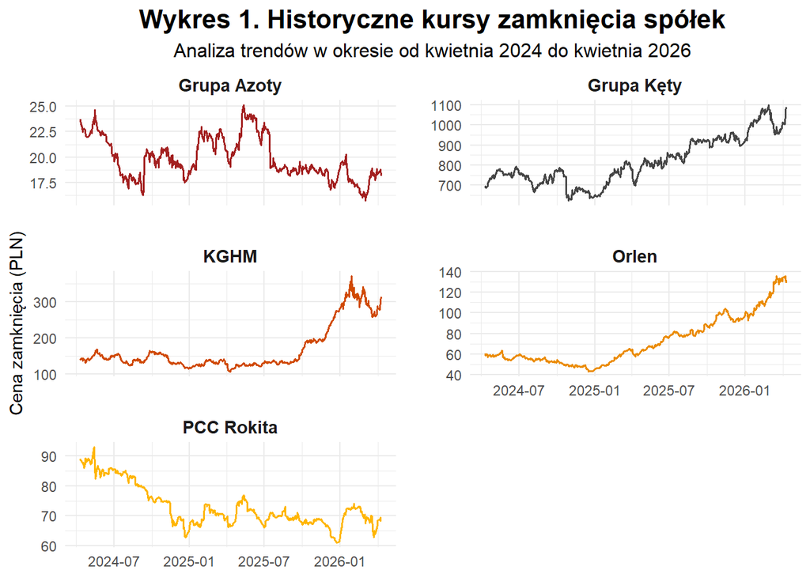

```r
#KROK 1 stworzenie palety kolorów
pwc_colors = c(
  "KGHM"        = "#D04A02",
  "Orlen"       = "#EB8C00",
  "PCC Rokita"  = "#FFB600",
  "Grupa Azoty" = "#A32020",
  "Grupa Kęty"  = "#464646"
)

#KROK 2 rysowanie wykresu
ggplot(df_long, aes(x = date, y = close, color = spolka, group = spolka)) +
  geom_line(linewidth = 0.7) +

  scale_color_manual(values = pwc_colors) +

  facet_wrap(~spolka, scales = "free_y", ncol = 2) +

  theme_minimal() +

  labs(
    title = "Wykres 1. Historyczne kursy zamknięcia spółek",
    subtitle = "Analiza trendów w okresie od kwietnia 2024 do kwietnia 2026",
    x = NULL,
    y = "Cena zamknięcia (PLN)"
  ) +

  theme(
    plot.title = element_text(hjust = 0.5, face = "bold", size = 16),
    plot.subtitle = element_text(hjust = 0.5, size = 12),
    strip.text = element_text(face = "bold", size = 11),
    panel.spacing = unit(1.5, "lines"),

    legend.position = "none"
  )
```

Wstępna analiza wizualna pozwala na identyfikację trendów, jednak formalna detekcja wartości odstających na poziomie cen zamknięcia nie jest metodologicznie uzasadniona.

W tym celu przeprowadzono test stacjonarności ADF, który pozwala ocenić, czy właściwości statystyczne szeregu (średnia i zmienność) pozostają stabilne w czasie.

Wyniki wskazują na brak stacjonarności analizowanych szeregów cen, co oznacza, że ich charakterystyka zmienia się wraz z warunkami rynkowymi.

Z perspektywy analitycznej oznacza to, że zarówno średnia, jak i zmienność mogą istotnie różnić się pomiędzy okresami, co ogranicza możliwość bezpośredniego porównywania obserwacji w czasie.

```r
#KROK 1 policzenie wyników testów
testy_stacjonarnosci = df_long %>%
  group_by(spolka) %>%
  summarise(
    p_value = adf.test(close)$p.value,
    czy_stacjonarny = ifelse(p_value < 0.05, "Tak", "Nie")
  )

#KROK 2 stworzenie tabeli
kable(
  testy_stacjonarnosci,
  col.names = c("Spółka", "p-value", "Stacjonarność"),
  align = "c",
  caption = "<span style='color:black; font-weight:700;'>Tabela 2. Wyniki testu ADF dla szeregów cen</span>",
  escape = FALSE
) %>%
  kable_styling(
    bootstrap_options = c("condensed"),
    full_width = FALSE,
    position = "center",
    font_size = 15
  ) %>%
  row_spec(
    0,
    bold = TRUE,
    color = "white",
    background = "#d35400"
  ) %>%
  column_spec(
    1,
    bold = TRUE,
    color = "white",
    background = "#d35400"
  )
```

Tabela 2. Wyniki testu ADF dla szeregów cen

| Spółka | p-value | Stacjonarność |
| --- | --- | --- |
| Grupa Azoty | 0.3474446 | Nie |
| Grupa Kęty | 0.2507612 | Nie |
| KGHM | 0.9245316 | Nie |
| Orlen | 0.9136048 | Nie |
| PCC Rokita | 0.4516576 | Nie |

# 5 Eksploracyjna analiza struktury

## 5.1 Transformacja do logarytmicznych stóp zwrotu

W dalszej analizie zamiast poziomów cen wykorzystano logarytmiczne stopy zwrotu, które lepiej oddają rzeczywistą dynamikę zmian wartości instrumentów.

W praktyce oznacza to przejście z analizy poziomu cen do analizy ich zmian w czasie, co pozwala na bardziej adekwatną ocenę wyników oraz ryzyka inwestycyjnego.

$$r_t = \ln\left(\frac{P_t}{P_{t-1}}\right)$$
Zastosowanie logarytmicznych stóp zwrotu ogranicza wpływ niestacjonarności obecnej w poziomach cen i pozwala analizować dane o bardziej stabilnych własnościach statystycznych. Dodatkowo ich addytywność w czasie upraszcza analizę zmian wartości w dłuższych horyzontach.

Z perspektywy analitycznej umożliwia to identyfikację rzeczywistych szoków rynkowych, bez ich mieszania z długoterminowymi trendami cenowymi.

Ma to szczególne znaczenie w analizie ryzyka (np. VaR), gdzie kluczowe są rozkłady stóp zwrotu, a nie poziomy cen.

```r
#KROK 1 policzenie logarytmicznych stóp zwrotu
df_long = df_long %>%
  group_by(spolka) %>%
  mutate(
    return_rate = (close / lag(close)) - 1,
    log_return = log(close / lag(close))
  )
```

Poniżej przedstawiono przebieg logarytmicznych stóp zwrotu dla analizowanych spółek.

Wizualizacja umożliwia szybką ocenę zmienności oraz identyfikację okresów podwyższonej niepewności rynkowej.

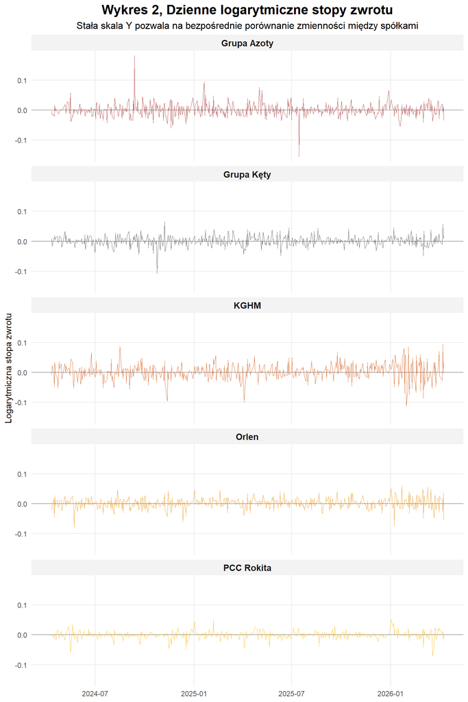

```r
#KROK 1 rysowanie wykresu
ggplot(df_long, aes(x = date, y = log_return, color = spolka)) +
  geom_hline(yintercept = 0, color = "black", alpha = 0.3, linetype = "solid") +
  geom_line(size = 0.3, alpha = 0.8) +
  facet_wrap(~spolka, scales = "fixed", ncol = 1) +
  theme_minimal() +
  scale_color_manual(values = pwc_colors) +
  labs(
    title = "Wykres 2, Dzienne logarytmiczne stopy zwrotu",
    subtitle = "Stała skala Y pozwala na bezpośrednie porównanie zmienności między spółkami",
    x = NULL,
    y = "Logarytmiczna stopa zwrotu"
  ) +
  theme_minimal() +
  theme(
    plot.title = element_text(hjust = 0.5, face = "bold", size = 16),
    plot.subtitle = element_text(hjust = 0.5, size = 12),
    strip.background = element_rect(fill = "#F3F3F3", color = NA),
    strip.text = element_text(face = "bold", size = 11),
    panel.grid.minor = element_blank(),
    legend.position = "none"
  )
```

## 5.2 Analiza stóp zwrotu

Na poniższym wykresie przedstawiono skumulowane stopy zwrotu dla analizowanych spółek. Stanowią one punkt wyjścia analizy, ponieważ bezpośrednio pokazują, które inwestycje generowały zyski, a które straty w badanym okresie.

Choć logarytmiczne stopy zwrotu nie są wprost równoważne klasycznym stopom zwrotu, pozwalają uchwycić kierunek zmian oraz relacje pomiędzy spółkami.

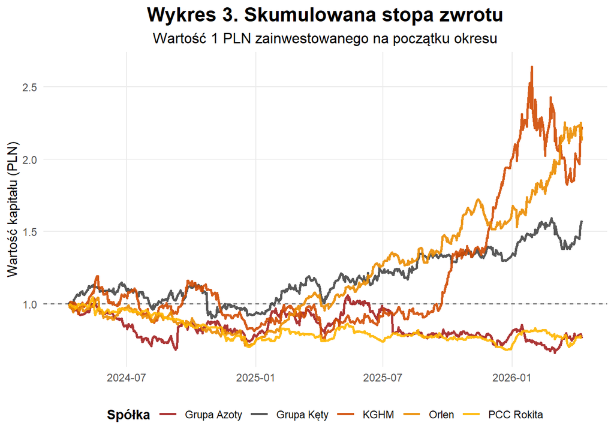

```r
#KROK 1 stworzenie agregacju
wykres_wealth_index = df_long %>%
  arrange(spolka, date) %>%
  group_by(spolka) %>%
  mutate(cum_return = exp(cumsum(replace_na(log_return, 0)))) %>%
  ungroup() %>%

  #KROK 2 budowa wykresu
  ggplot(aes(x = date, y = cum_return, color = spolka)) +
  geom_hline(yintercept = 1, linetype = "dashed", color = "#464646", size = 0.5) +
  geom_line(linewidth = 0.9, alpha = 0.9) +
  scale_color_manual(values = pwc_colors) +
  labs(
    title = "Wykres 3. Skumulowana stopa zwrotu",
    subtitle = "Wartość 1 PLN zainwestowanego na początku okresu",
    x = NULL,
    y = "Wartość kapitału (PLN)",
    color = "Spółka"
  ) +
  theme_minimal() +
  theme(
    plot.title = element_text(hjust = 0.5, face = "bold", size = 16),
    plot.subtitle = element_text(hjust = 0.5, size = 12),
    legend.position = "bottom",
    legend.title = element_text(face = "bold"),
    panel.grid.minor = element_blank()
  )

print(wykres_wealth_index)
```

```r
#KROK 1 obliczenie agregacji
tabela_wealth_pwc = df_long %>%
  group_by(spolka) %>%
  summarise(
    Suma_Log_Return = sum(log_return, na.rm = TRUE),
    Wartosc_Zainwestowanej_Zlotowki = exp(Suma_Log_Return),
    Wynik_Procentowy = (Wartosc_Zainwestowanej_Zlotowki - 1) * 100
  ) %>%
  arrange(desc(Wynik_Procentowy)) %>%
  mutate(across(where(is.numeric), ~ round(., 2)))

#KROK 2 stworzenie tabeli
tabela_wealth_pwc %>%
  kable(
    caption = "<div style='text-align: center; font-weight:700; color:black;'>Tabela 3. Podsumowanie wyników inwestycyjnych</div>",
    col.names = c(
      "Spółka",
      "Suma log-zwrotów",
      "Wartość zainwestowanej złotówki",
      "Łączny zwrot (%)"
    ),
    align = "lccc",
    escape = FALSE
  ) %>%
  kable_styling(
    bootstrap_options = c("condensed"),
    full_width = FALSE,
    position = "center",
    font_size = 15
  ) %>%
  row_spec(
    0,
    bold = TRUE,
    color = "white",
    background = "#d35400"
  ) %>%
  column_spec(
    1,
    bold = TRUE,
    color = "white",
    background = "#d35400"
  ) %>%
  column_spec(
    4,
    bold = TRUE,
    color = ifelse(tabela_wealth_pwc$Wynik_Procentowy >= 0, "#2E7D32", "#C62828")
  )
```

Tabela 3. Podsumowanie wyników inwestycyjnych

| Spółka | Suma log-zwrotów | Wartość zainwestowanej złotówki | Łączny zwrot (%) |
| --- | --- | --- | --- |
| KGHM | 0.80 | 2.22 | 122.24 |
| Orlen | 0.76 | 2.13 | 112.92 |
| Grupa Kęty | 0.46 | 1.58 | 57.63 |
| PCC Rokita | -0.26 | 0.77 | -23.14 |
| Grupa Azoty | -0.27 | 0.77 | -23.42 |

**Wnioski z wyników**

W badanym okresie obserwujemy wyraźne zróżnicowanie wyników – część spółek generowała wysokie zyski, podczas gdy inne przynosiły straty.

**Liderzy wzrostów**  
**KGHM** – zdecydowany lider; wartość inwestycji wzrosła do 2,22 PLN (ok. +122%)  
**Orlen** – bardzo zbliżony wynik (ok. +113%)

**Stabilny wzrost**  
**Grupa Kęty** – dodatnia stopa zwrotu na poziomie ok. +58%, co wskazuje na stabilny, choć mniej dynamiczny wzrost.

**Spółki ze stratą**  
**PCC Rokita** – ok. -23%  
**Grupa Azoty** – ok. -23%

W obu przypadkach oznacza to realną utratę części zainwestowanego kapitału.

**Wniosek**  
Wyniki portfela były w dużej mierze determinowane przez największe podmioty, w szczególności KGHM i Orlen.

## 5.3 Analiza tendencji centralnej i dyseprsji

```r
#KROK 1 policzenie statystyk opisowych
statystyki_opisowe = df_long %>%
  group_by(spolka) %>%
  summarise(
    Srednia = mean(log_return, na.rm = TRUE),
    Mediana = median(log_return, na.rm = TRUE),
    Odchylenie_standardowe = sd(log_return, na.rm = TRUE),
    Min = min(log_return, na.rm = TRUE),
    Q1 = quantile(log_return, 0.25, na.rm = TRUE),
    Q3 = quantile(log_return, 0.75, na.rm = TRUE),
    Max = max(log_return, na.rm = TRUE)
  ) %>%
  mutate(across(where(is.numeric), ~ round(., 4)))

#KROK 2 stworzenie tabeli
statystyki_opisowe %>%
  kable(
    caption = "<div style='text-align: center; font-weight:700; color:black;'>Tabela 4. Statystyki opisowe logarytmicznych stóp zwrotu</div>",
    col.names = c(
      "Spółka",
      "Średnia",
      "Mediana",
      "Odchylenie standardowe",
      "Min",
      "Q1",
      "Q3",
      "Max"
    ),
    align = "lccccccc",
    escape = FALSE
  ) %>%
  kable_styling(
    bootstrap_options = c("condensed"),
    full_width = FALSE,
    position = "center",
    font_size = 14
  ) %>%

  row_spec(
    0,
    bold = TRUE,
    color = "white",
    background = "#d35400"
  ) %>%

  column_spec(
    1,
    bold = TRUE,
    color = "white",
    background = "#d35400"
  )
```

Tabela 4. Statystyki opisowe logarytmicznych stóp zwrotu

| Spółka | Średnia | Mediana | Odchylenie standardowe | Min | Q1 | Q3 | Max |
| --- | --- | --- | --- | --- | --- | --- | --- |
| Grupa Azoty | -0.0005 | -0.0017 | 0.0228 | -0.1555 | -0.0137 | 0.0113 | 0.1820 |
| Grupa Kęty | 0.0009 | 0.0006 | 0.0169 | -0.1068 | -0.0087 | 0.0100 | 0.0660 |
| KGHM | 0.0016 | 0.0007 | 0.0266 | -0.1132 | -0.0118 | 0.0161 | 0.0939 |
| Orlen | 0.0015 | 0.0026 | 0.0179 | -0.0818 | -0.0082 | 0.0116 | 0.0594 |
| PCC Rokita | -0.0005 | 0.0000 | 0.0126 | -0.0698 | -0.0057 | 0.0046 | 0.0524 |

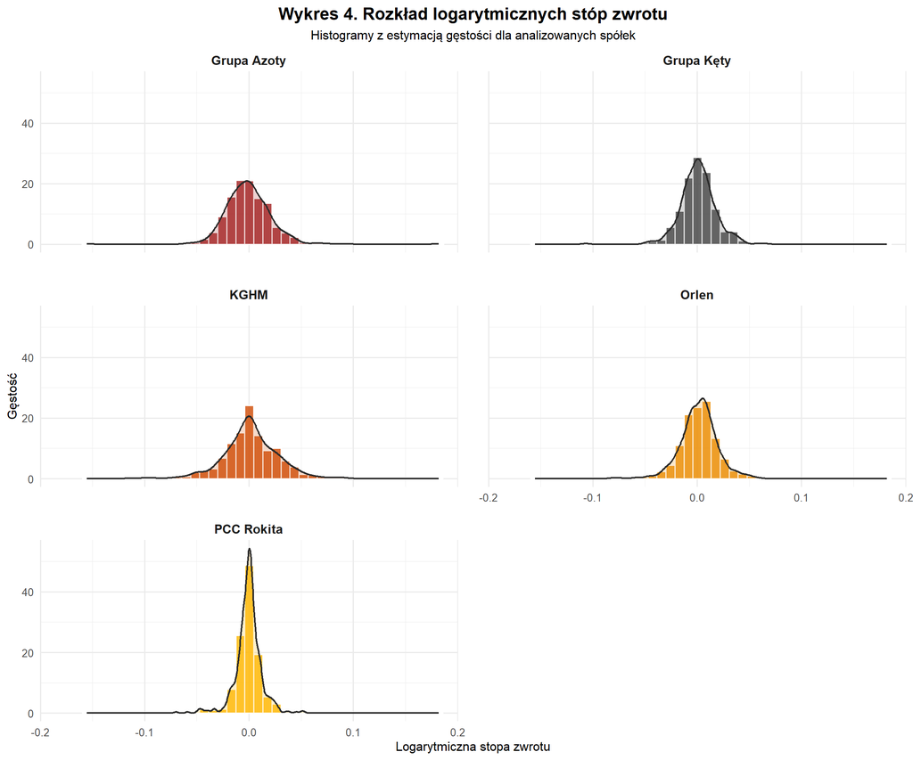

```r
#KROK 1 symetryczny zakres osi x
max_abs = max(abs(df_long$log_return), na.rm = TRUE)

#KROK 2 stworzenie wykresu
ggplot(df_long, aes(x = log_return, fill = spolka)) +
  geom_histogram(
    aes(y = after_stat(density)),
    bins = 40,
    color = "white",
    alpha = 0.8
  ) +
  geom_density(
    color = "#2b2b2b",
    linewidth = 0.8,
    alpha = 0.2
  ) +
  facet_wrap(~spolka, scales = "fixed", ncol = 2) +
  scale_fill_manual(values = pwc_colors) +
  coord_cartesian(xlim = c(-max_abs, max_abs)) +

  labs(
    title = "Wykres 4. Rozkład logarytmicznych stóp zwrotu",
    subtitle = "Histogramy z estymacją gęstości dla analizowanych spółek",
    x = "Logarytmiczna stopa zwrotu",
    y = "Gęstość"
  ) +

  theme_minimal(base_size = 13) +

  theme(
    plot.title = element_text(hjust = 0.5, face = "bold", size = 16),
    plot.subtitle = element_text(hjust = 0.5, size = 12),
    strip.text = element_text(face = "bold", size = 12),
    panel.spacing = unit(2, "lines"),
    legend.position = "none",
    axis.text = element_text(size = 10),
    axis.title = element_text(size = 12)
  )
```

**Średnia stopa zwrotu**  
**KGHM (0,0016)** i **Orlen (0,0015)** osiągają najwyższe średnie stopy zwrotu – potwierdza to ich silny trend wzrostowy.  
**Grupa Kęty (0,0009)** – dodatnia średnia, jednak przy wyraźnie niższej dynamice wzrostu.  
**PCC Rokita** i **Grupa Azoty (~ -0,0005)** – ujemne średnie, co wskazuje na brak długoterminowego wzrostu wartości.

**Potwierdza to zależność obserwowana w skumulowanych stopach zwrotu.**

**Mediana (typowe zachowanie)**  
Mediany są bliskie zeru dla większości spółek – dzienne zmiany mają zazwyczaj niewielką skalę.  
**Orlen (0,0026)** wyróżnia się dodatnią medianą – częściej notuje wzrosty niż spadki.  
**Grupa Azoty (-0,0017)** – przewaga dni spadkowych.

**Zmienność (ryzyko)**  
**KGHM (0,0266)** – najwyższe odchylenie standardowe. Jednocześnie najwyższy potencjał zysku, ale też największe ryzyko, szczególnie w krótkim horyzoncie inwestycyjnym.  
**Grupa Azoty (0,0228)** – wysoka zmienność przy ujemnym trendzie, co oznacza niekorzystny profil ryzyko/zwrot.  
**PCC Rokita (0,0126)** – najniższa zmienność. Większa stabilność, jednak w tym przypadku nie ma ona pozytywnego charakteru – przy ujemnych stopach zwrotu oznacza raczej systematyczny, powolny spadek wartości i stagnację.

**Wartości skrajne (ekstrema)**

Największe wzrosty:  
- **Grupa Azoty (+19%, 12.09.2024)** – informacja o podpisaniu listu intencyjnego z PKN Orlen dotyczącego projektu Polyolefins  
- **KGHM (+9,4%, 08.04.2026)** – ogłoszenie dwutygodniowego rozejmu między USA, co poprawiło sentyment do metali przemysłowych

Największe spadki:  
- **Grupa Azoty (-15,5%, 15.07.2025)** – kontynuacja problemów projektu Polyolefins; Orlen zrezygnował z przejęcia udziałów w zadłużonym projekcie  
- **KGHM (-11,3%, 30.01.2026)** – nagłe odwołanie prezesa Andrzeja Szydło oraz wiceprezesa Piotra Stryczka

**Wniosek**  
- Spółki o najwyższych stopach zwrotu (**KGHM, Orlen**) charakteryzują się odmienną specyfiką. Orlen wykazuje niższą zmienność i bardziej liniowy wzrost, natomiast **KGHM**, mimo większych wahań, osiąga najwyższe stopy zwrotu.  
- **Grupa Azoty** stanowi ciekawy przypadek – duże dodatnie skoki mogą być wykorzystywane w krótkim horyzoncie, jednak w ujęciu długoterminowym spółka generuje straty.  
- **Grupa Kęty** plasuje się pośrodku – stosunkowo stabilna, ale z mniej dynamicznym wzrostem niż liderzy. Można ją traktować jako instrument umiarkowanie opłacalny.  
- **PCC Rokita** wypada najsłabiej – niska zmienność wynika raczej z powolnego, systematycznego spadku wartości. Spółka nie daje istotnych możliwości ani w ujęciu długoterminowym, ani krótkoterminowym.

## 5.4 Analiza skośności i kurtozy

**Dlaczego to jest istotne?**  
Standardowe miary, takie jak średnia i odchylenie standardowe, nie oddają pełnego obrazu ryzyka. Kluczowe znaczenie ma skala oraz częstość występowania ekstremalnych ruchów cen.

**Skośność (asymetria rozkładu)**  
- wskazuje kierunek asymetrii rozkładu  
- ujemna skośność → większe ryzyko nagłych spadków  
- dodatnia skośność → większe prawdopodobieństwo silnych wzrostów

**Kurtoza (ekstremalne zdarzenia)**  
- informuje o intensywności występowania wartości skrajnych  
- wysoka kurtoza → większe ryzyko gwałtownych ruchów  
- w praktyce oznacza obecność tzw. „grubych ogonów”

```r
#KROK 1 policzenie skosnosci i kurtozy
statystyki_wyzsze = df_long %>%
  group_by(spolka) %>%
  summarise(
    Skosnosc = skewness(log_return, na.rm = TRUE),
    Kurtoza = kurtosis(log_return, na.rm = TRUE)
  ) %>%
  mutate(across(where(is.numeric), ~ round(., 2)))

#KROK 2 stworzenie tabeli
statystyki_wyzsze %>%
  kable(
    caption = "<div style='text-align: center; font-weight:700; color:black;'>Tabela 6. Skośność i kurtoza logarytmicznych stóp zwrotu</div>",
    col.names = c(
      "Spółka",
      "Skośność",
      "Kurtoza"
    ),
    align = "lcc",
    escape = FALSE
  ) %>%
  kable_styling(
    bootstrap_options = c("condensed"),
    full_width = FALSE,
    position = "center",
    font_size = 14
  ) %>%
  row_spec(
    0,
    bold = TRUE,
    color = "white",
    background = "#d35400"
  ) %>%
  column_spec(
    1,
    bold = TRUE,
    color = "white",
    background = "#d35400"
  )
```

Tabela 6. Skośność i kurtoza logarytmicznych stóp zwrotu

| Spółka | Skośność | Kurtoza |
| --- | --- | --- |
| Grupa Azoty | 0.74 | 15.17 |
| Grupa Kęty | -0.32 | 6.74 |
| KGHM | -0.20 | 4.84 |
| Orlen | -0.32 | 5.01 |
| PCC Rokita | -0.61 | 8.24 |

**Grupa Azoty**  
- Bardzo wysoka kurtoza (15,17) → częste występowanie zdarzeń skrajnych  
- Pomimo trendu spadkowego pojawiają się silne ruchy w obie strony  
- Spółka o wysokiej zmienności „eventowej” → potencjał dla strategii krótkoterminowych (long/short)

**KGHM**  
- Wysokie odchylenie standardowe przy relatywnie niższej kurtozie  
- Zmienność ma bardziej „rozłożony” charakter – ruchy są częste, ale rzadziej ekstremalne  
- Profil: wysoka zmienność, ale bez dominacji nagłych tąpnięć

**Orlen**  
- Umiarkowana skośność i niższa intensywność zdarzeń skrajnych  
- Rozkład bardziej stabilny w porównaniu do pozostałych spółek  
- Profil: bardziej przewidywalny przebieg stóp zwrotu

**Grupa Kęty**  
- Skośność zbliżona do Orlenu, ale większa podatność na zdarzenia skrajne  
- Większa „nieregularność” rozkładu mimo umiarkowanej zmienności  
- Profil: stabilny trend, ale z epizodami silniejszych ruchów

**PCC Rokita**  
- Niska zmienność (odchylenie standardowe), ale podwyższona kurtoza  
- Na tle stabilnych zmian pojawiają się sporadyczne, wyraźniejsze skoki  
- Profil: spokojny przebieg z okazjonalnymi odchyleniami

**Wniosek ogólny** - Wszystkie spółki wykazują kurtozę > 3 - obecność „grubych ogonów” rozkładu - Rozkłady wyraźnie odbiegają od normalnego - Ryzyko ekstremalnych zdarzeń jest istotne i nie może być pomijane w analizie

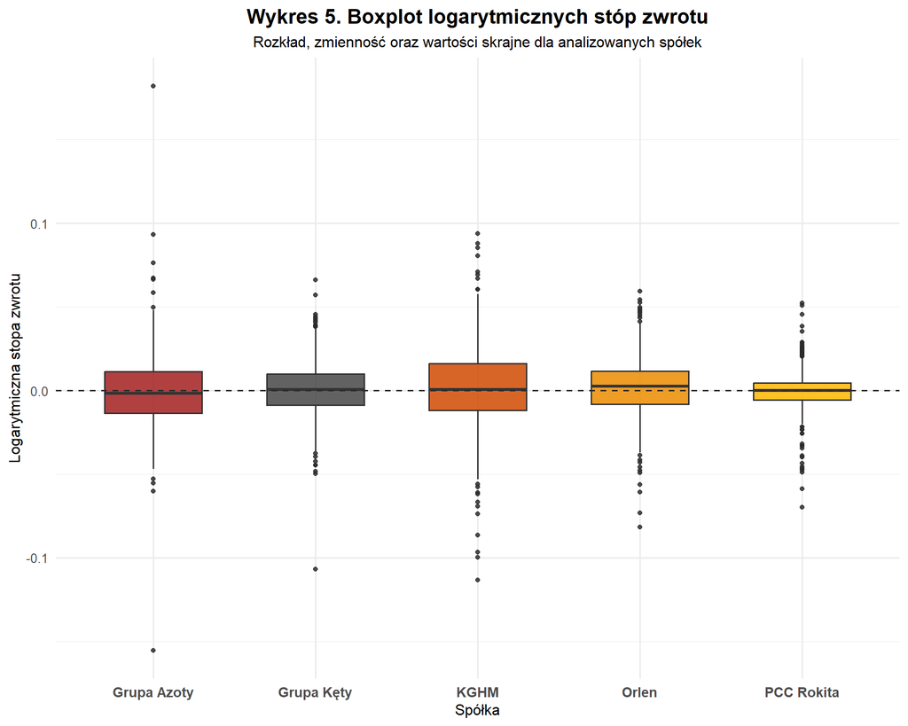

```r
#KROK 1 stworzenie wykresu
ggplot(df_long, aes(x = spolka, y = log_return, fill = spolka)) +
  geom_boxplot(
    width = 0.6,
    outlier.color = "#2b2b2b",
    outlier.size = 1.5,
    alpha = 0.85
  ) +
  scale_fill_manual(values = pwc_colors) +

  geom_hline(
    yintercept = 0,
    linetype = "dashed",
    color = "#2b2b2b",
    linewidth = 0.6
  ) +

  labs(
    title = "Wykres 5. Boxplot logarytmicznych stóp zwrotu",
    subtitle = "Rozkład, zmienność oraz wartości skrajne dla analizowanych spółek",
    x = "Spółka",
    y = "Logarytmiczna stopa zwrotu"
  ) +

  theme_minimal(base_size = 13) +

  theme(
    plot.title = element_text(hjust = 0.5, face = "bold", size = 16),
    plot.subtitle = element_text(hjust = 0.5, size = 12),

    legend.position = "none",

    axis.text.x = element_text(size = 11, face = "bold"),
    axis.text.y = element_text(size = 10),

    axis.title = element_text(size = 12)
  )
```

Powyższa wizualizacja (boxplot) podkreśla znaczenie obserwacji skrajnych w danych finansowych. Widoczne odchylenia wartości odstających względem zakresu typowych obserwacji potwierdzają istotną rolę ekstremalnych zdarzeń, co jest spójne z wcześniej obserwowaną wysoką kurtozą.

Na poziomie porównawczym widoczne są również różnice pomiędzy spółkami. **KGHM** charakteryzuje się wyższym poziomem ryzyka niż **Orlen**, pomimo zbliżonych stóp zwrotu.

**PCC Rokita** wyróżnia się natomiast specyficzną strukturą rozkładu – większość stóp zwrotu koncentruje się blisko zera, przy jednoczesnym występowaniu sporadycznych, wyraźnych odchyleń.

**Podsumowanie**  
Uzyskane wyniki stanowią podstawę do dalszego modelowania ryzyka, w szczególności estymacji miar takich jak VaR.

# 6 Analiza współzależności

## 6.1 Korelacja liniowa Pearsona

Kolejnym etapem analizy jest ocena współzależności pomiędzy stopami zwrotu analizowanych instrumentów. Z perspektywy budowy portfela ma to kluczowe znaczenie, ponieważ niższa korelacja pomiędzy aktywami sprzyja efektywnej dywersyfikacji ryzyka.

Na poniższym wykresie przedstawiono mapę cieplną współczynników korelacji Pearsona, stanowiących standardową miarę siły i kierunku zależności pomiędzy zmiennymi.

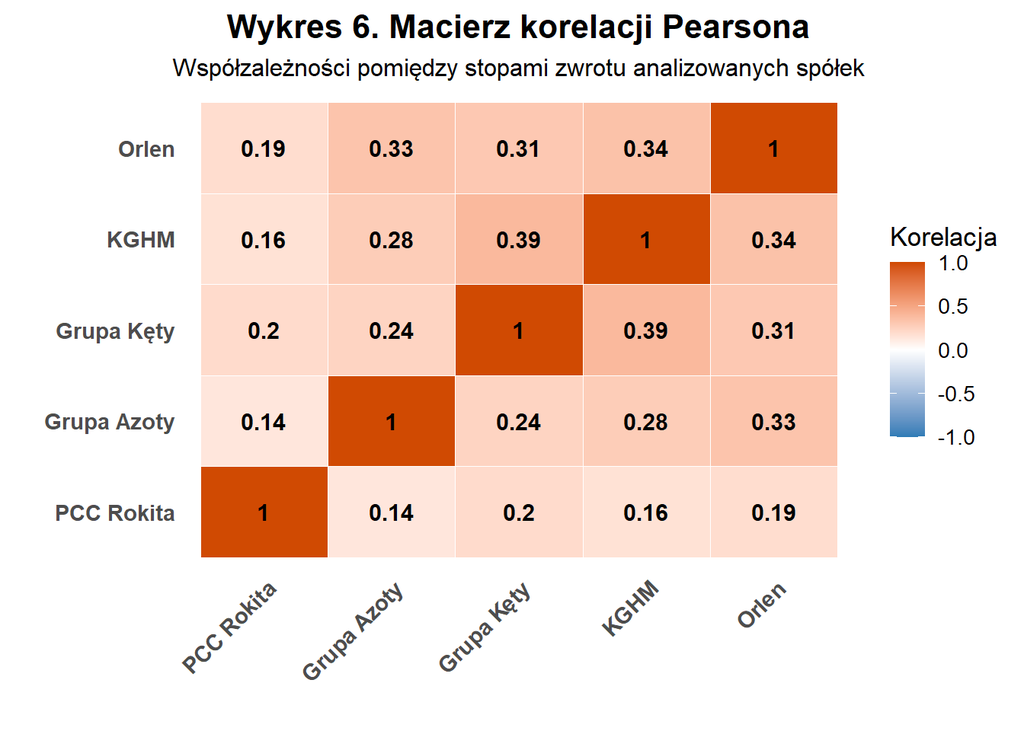

```r
#KROK 1 transformacja na format wide
df_wide = df_long %>%
  select(date, spolka, log_return) %>%
  pivot_wider(names_from = spolka, values_from = log_return)

#KROK 2 macierz korelacji pearsona
korelacje = cor(df_wide %>% select(-date), use = "complete.obs")

#KROK 3 dostosowanie do formatu long
korelacje_long = melt(korelacje)

#KROK 4 budowa wykresu
ggplot(korelacje_long, aes(x = Var1, y = Var2, fill = value)) +
  geom_tile(color = "white") +

  geom_text(aes(label = round(value, 2)), size = 4, fontface = "bold") +

  scale_fill_gradient2(
    low = "#2c7bb6",
    mid = "white",
    high = "#d04a02",
    midpoint = 0,
    limits = c(-1, 1)
  ) +

  labs(
    title = "Wykres 6. Macierz korelacji Pearsona",
    subtitle = "Współzależności pomiędzy stopami zwrotu analizowanych spółek",
    x = "",
    y = "",
    fill = "Korelacja"
  ) +

  theme_minimal(base_size = 13) +

  theme(
    plot.title = element_text(hjust = 0.5, face = "bold", size = 16),
    plot.subtitle = element_text(hjust = 0.5, size = 12),
    axis.text.x = element_text(angle = 45, hjust = 1, size = 11, face = "bold"),
    axis.text.y = element_text(size = 11, face = "bold"),
    panel.grid = element_blank()
  )
```

**Ogólny obraz**  
- Korelacje pomiędzy wszystkimi spółkami są dodatnie → tendencja do poruszania się w tym samym kierunku  
- Jednocześnie ich poziom jest relatywnie niski → ograniczona siła zależności

**Siła zależności**  
- Najwyższe korelacje (ok. 0,30–0,39):  
- KGHM – Grupa Kęty (0,39)  
- Orlen – KGHM / Azoty (~0,33–0,34)  
- Są to jednak wartości umiarkowane, dalekie od silnej współzależności

**Ograniczenia korelacji Pearsona**  
- stanowi użyteczne narzędzie do wstępnej oceny zależności  
- nie uwzględnia w pełni:  
- zależności nieliniowych  
- wpływu wartości skrajnych

W przypadku danych finansowych może nie oddawać pełnej struktury relacji

**Implikacja analityczna**  
- rozkłady stóp zwrotu odbiegają od normalnego (potwierdzone wcześniej analizą kurtozy)  
- formalna weryfikacja została przeprowadzona testem Jarque–Bera

```r
#KROK 1 policzenie testu JB
jb_test = df_long %>%
  na.omit() %>%
  group_by(spolka) %>%
  summarise(
    JB_stat = jarque.bera.test(log_return)$statistic,
    p_value = jarque.bera.test(log_return)$p.value,
    .groups = "drop"
  ) %>%
  mutate(
    p_value = signif(p_value, 3),
    Normalnosc = ifelse(p_value < 0.05, "Nie", "Tak")
  )

#KROK 2 stworzenie tabeli
jb_test %>%
  select(spolka, p_value, Normalnosc) %>%
  kable(
    caption = "<div style='text-align: center; font-weight:700; color:black;'>Tabela 7. Test normalności Jarque–Bera</div>",
    col.names = c("Spółka", "p-value", "Czy rozkład normalny"),
    align = "lcc",
    escape = FALSE
  ) %>%
  kable_styling(
    bootstrap_options = c("condensed"),
    full_width = FALSE,
    position = "center",
    font_size = 14
  ) %>%
  row_spec(
    0,
    bold = TRUE,
    color = "white",
    background = "#d35400"
  ) %>%
  column_spec(
    1,
    bold = TRUE,
    color = "white",
    background = "#d35400"
  ) %>%
  column_spec(
    3,
    bold = TRUE,
    color = ifelse(jb_test$Normalnosc == "Nie", "#C62828", "#2E7D32")
  )
```

Tabela 7. Test normalności Jarque–Bera

| Spółka | p-value | Czy rozkład normalny |
| --- | --- | --- |
| Grupa Azoty | 0 | Nie |
| Grupa Kęty | 0 | Nie |
| KGHM | 0 | Nie |
| Orlen | 0 | Nie |
| PCC Rokita | 0 | Nie |

**Wyniki**  
Test wskazuje na odrzucenie hipotezy normalności rozkładu, co potwierdza obecność „grubych ogonów” oraz asymetrii.

W konsekwencji korelacje Pearsona należy interpretować ostrożnie – jako przybliżenie zależności, które nie uwzględnia pełnej struktury współzależności pomiędzy instrumentami.

## 6.2 Korelacja odległościowa

**Co zamiast korelacji Pearsona?**

W związku z powyższymi ograniczeniami zasadne jest zastosowanie alternatywnych miar zależności. Jedną z nich jest korelacja odległościowa (*distance correlation*), która pozwala wykrywać zarówno zależności liniowe, jak i nieliniowe.

Miara ta jest mniej wrażliwa na brak normalności rozkładu oraz obecność wartości skrajnych, co czyni ją szczególnie użyteczną w analizie danych finansowych.

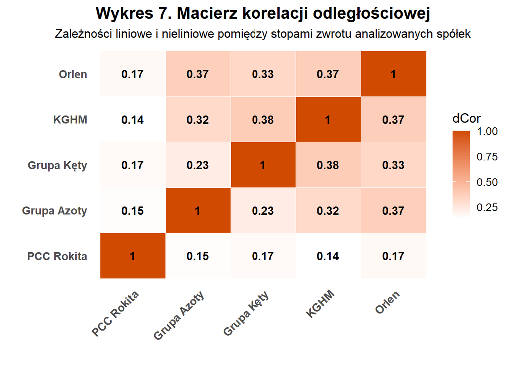

```r
#KROK 1 dane do formatu wide
df_wide = df_long %>%
  select(date, spolka, log_return) %>%
  pivot_wider(names_from = spolka, values_from = log_return) %>%
  na.omit()

#KROK 2 nazwy spolek
spolki = colnames(df_wide)[-1]

#KROK 3 macierz korelacji odległościowej
dcor_matrix = matrix(NA, nrow = length(spolki), ncol = length(spolki))
rownames(dcor_matrix) = spolki
colnames(dcor_matrix) = spolki

for (i in seq_along(spolki)) {
  for (j in seq_along(spolki)) {
    dcor_matrix[i, j] = dcor(df_wide[[spolki[i]]], df_wide[[spolki[j]]])
  }
}


#KROK 4 long format do heatmapy
dcor_long = melt(dcor_matrix)

#KROK 5 mapa cieplna
ggplot(dcor_long, aes(x = Var1, y = Var2, fill = value)) +
  geom_tile(color = "white") +

  geom_text(aes(label = round(value, 2)), size = 4, fontface = "bold") +

  scale_fill_gradient(
    low = "white",
    high = "#d04a02"
  ) +

  labs(
    title = "Wykres 7. Macierz korelacji odległościowej",
    subtitle = "Zależności liniowe i nieliniowe pomiędzy stopami zwrotu analizowanych spółek",
    x = "",
    y = "",
    fill = "dCor"
  ) +

  theme_minimal(base_size = 13) +

  theme(
    plot.title = element_text(hjust = 0.5, face = "bold", size = 16),
    plot.subtitle = element_text(hjust = 0.5, size = 12),
    axis.text.x = element_text(angle = 45, hjust = 1, size = 11, face = "bold"),
    axis.text.y = element_text(size = 11, face = "bold"),
    panel.grid = element_blank()
  )
```

**Wnioski z analizy korelacji** Pomimo wyraźnych odchyleń od normalności rozkładów, analiza korelacji odległościowej nie wskazuje na istotne zależności nieliniowe pomiędzy stopami zwrotu.  
—  
W praktyce oznacza to, że obserwowane współzależności są ograniczone (słabe lub umiarkowane) i – tam gdzie występują – mają głównie charakter liniowy.

## 6.3 Grupowanie spółek

Hierarchiczna analiza skupień pozwala ocenić podobieństwo zachowań spółek, wychodząc poza analizę pojedynczych korelacji.

Na podstawie korelacji Pearsona instrumenty są grupowane według stopnia współzależności – spółki o najbardziej zbliżonych profilach łączą się w pierwszej kolejności.

Dendrogram pokazuje, które spółki faktycznie zachowują się podobnie, a tym samym gdzie dywersyfikacja portfela jest ograniczona, a gdzie realna.

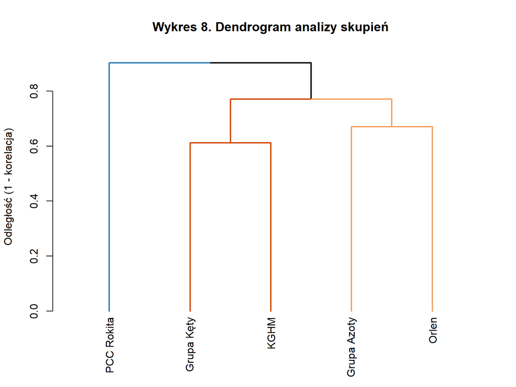

```r
#KROK 1 policzenie macierzy odległości
dist_matrix = as.dist(1 - korelacje)

#KROK 2 hierarchiczna analiza skupień metodą warda
hc = hclust(dist_matrix, method = "ward.D2")

#KROK 3 stworzenie dendrogramu
dend = as.dendrogram(hc)

#KROK 4 kolorowanie grup
dend <- color_branches(dend, k = 3,
                       col = c("#2c7bb6",
                               "#d04a02",
                               "#f4a261"))

dend <- set(dend, "branches_lwd", 2)

#KROK 5 stworzenie wykresu
plot(
  dend,
  main = "Wykres 8. Dendrogram analizy skupień",
  ylab = "Odległość (1 - korelacja)"
)
```

## 6.4 Kluczowe wnioski z dendrogramu

Analizowane spółki **nie tworzą jednorodnej grupy** – ogólnie niski poziom podobieństwa wskazuje na potencjał dywersyfikacyjny w portfelu.

**PCC Rokita = wyraźny outlier**  
- najpóźniejsze połączenie w dendrogramie  
- **profil stóp zwrotu istotnie różny od reszty rynku**  
- spójne z wcześniejszą analizą (boxplot):  
- wysoka koncentracja wokół średniej  
- obecność silnych wartości skrajnych

**Insight portfelowy** Część spółek (np. **KGHM – Kęty**) może być **redundantna z perspektywy ryzyka**

## 6.5 Korelacja w czasach kryzysu

W analizie danych finansowych kluczowe znaczenie mają ich własności statystyczne – w szczególności **stacjonarność** oraz **normalność rozkładu**.

Choć brak normalności (co zostało wcześniej potwierdzone) nie wyklucza zastosowania korelacji liniowej, to **niestacjonarność stanowi istotne ograniczenie interpretacyjne**. Oznacza ona, że relacje pomiędzy zmiennymi nie są stałe w czasie, lecz zależą od aktualnego otoczenia rynkowego.

Z tego względu analiza współzależności została rozszerzona poza ujęcie statyczne. Oprócz pełnego okresu badawczego uwzględniono również **warunki podwyższonego stresu rynkowego**, w których mechanizmy rynkowe ulegają istotnym zmianom.

W praktyce zarządzania ryzykiem wskazuje się, że: - w okresach kryzysowych **dywersyfikacja może zawodzić**,  
- a korelacje pomiędzy aktywami mają tendencję do **zacieśniania się** (*flight to correlation*).

W celu weryfikacji tej zależności przeanalizowano zachowanie korelacji w trakcie **eskalacji konfliktu geopolitycznego Iran–USA** w okresie od **28.02.2026 do 06.04.2026**.

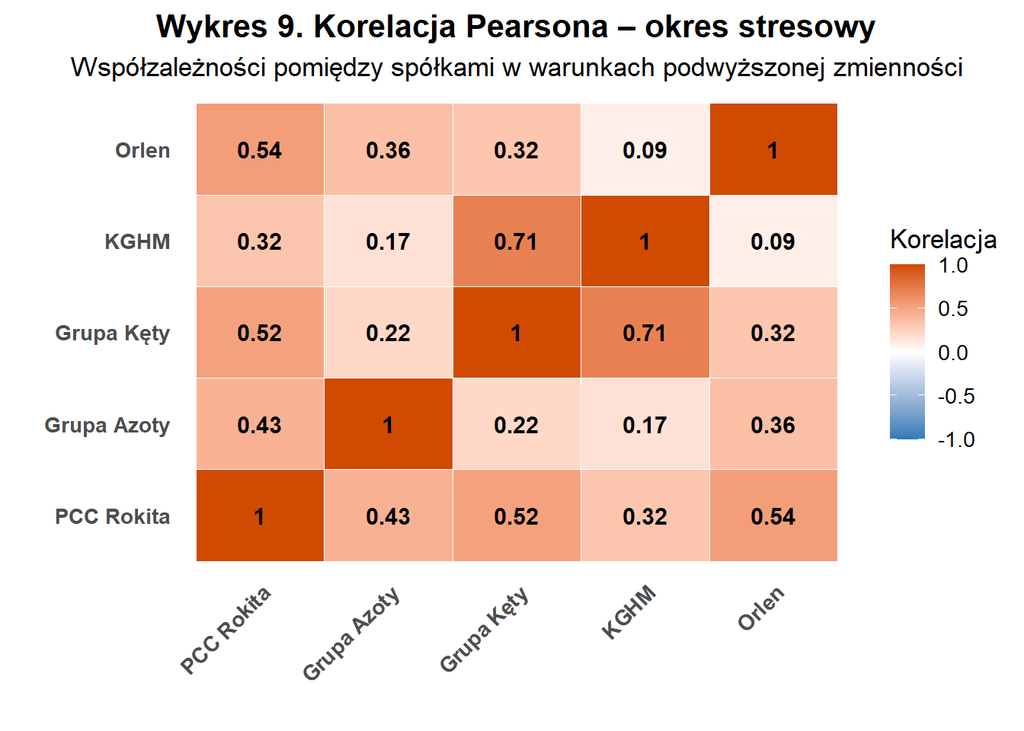

```r
#KROK 1 przefiltrowanie danych
crisis_wide = df_long %>%
  filter(date >= as.Date("2026-02-28") & date <= as.Date("2026-04-06")) %>%
  select(date, spolka, log_return) %>%
  pivot_wider(names_from = spolka, values_from = log_return) %>%
  na.omit()

#KROK 2 policzenie korelacji pearsona
corr_crisis = crisis_wide %>%
  select(-date) %>%
  cor(use = "pairwise.complete.obs")

#KROK 3 stworzenie heatmapy
ggplot(melt(corr_crisis), aes(x = Var1, y = Var2, fill = value)) +
  geom_tile(color = "white") +

  geom_text(aes(label = round(value, 2)), size = 4, fontface = "bold") +

  scale_fill_gradient2(
    low = "#2c7bb6",
    mid = "white",
    high = "#d04a02",
    midpoint = 0,
    limits = c(-1, 1)
  ) +

  labs(
    title = "Wykres 9. Korelacja Pearsona – okres stresowy",
    subtitle = "Współzależności pomiędzy spółkami w warunkach podwyższonej zmienności",
    x = "",
    y = "",
    fill = "Korelacja"
  ) +

  theme_minimal(base_size = 13) +

  theme(
    plot.title = element_text(hjust = 0.5, face = "bold"),
    plot.subtitle = element_text(hjust = 0.5),
    axis.text.x = element_text(angle = 45, hjust = 1, face = "bold"),
    axis.text.y = element_text(face = "bold"),
    panel.grid = element_blank()
  )
```

**Kluczowy insight z okresu stresowego**

- w warunkach kryzysowych wyraźnie rośnie nie tylko siła zależności, ale zmienia się również ich układ
- oznacza to, że kryzys **przebudowuje strukturę współzależności** pomiędzy spółkami, a nie tylko mechanicznie zwiększa wszystkie korelacje

**Orlen – KGHM**  
- w pełnym okresie była to jedna z najwyższych korelacji  
- w okresie stresowym relacja ta spadła do jednego z najniższych poziomów

**Wniosek:** podobieństwo obserwowane w spokojnych warunkach nie musi utrzymywać się w czasie szoku rynkowego

**Skutki dla portfela** - nie doszło do pełnego „zaniku dywersyfikacji”  
- jednak kryzys wyraźnie zmienił zasady gry  
- historyczna struktura korelacji może być niewystarczająca do oceny zachowania portfela w warunkach stresowych

## 6.6 Wnioski z analizy korelacji

**Ogólny obraz**  
- korelacje dodatnie - wspólna ekspozycja na czynniki makro (surowce, energia)  
- brak naturalnych „hedge’ów” w portfelu (brak korelacji ujemnych)  
- umiarkowany poziom zależności - pozorna dywersyfikacja

**Zachowanie w kryzysie**  
- korelacje nie są stałe – zmieniają się wraz z warunkami rynkowymi  
- w okresach stresu następuje **przebudowa struktury zależności**  
- dywersyfikacja działa inaczej niż w spokojnym otoczeniu

**Implikacje portfelowe** - pojedyncza macierz korelacji ≠ pełna ocena dywersyfikacji  
- konieczna analiza w różnych reżimach rynkowych  
- korelacje należy traktować jako **zmienne w czasie**, a nie stałe parametry

**Kluczowy insight**  
> Dywersyfikacja nie znika całkowicie w kryzysie – ale jej mechanizm działania ulega zmianie.

# 7 Podsumowanie

> Przeprowadzona analiza stanowi punkt wyjścia do dalszego modelowania ryzyka rynkowego i koncentruje się na zrozumieniu struktury danych oraz charakterystyki analizowanego portfela.

> W przypadku danych finansowych szczególna ostrożność jest niezbędna – metody statystyczne skuteczne w innych dziedzinach mogą w warunkach rynkowych okazać się niewystarczające. Wynika to ze zmienności otoczenia, która wpływa na ich interpretację oraz użyteczność.

> Kluczowe znaczenie ma podejście uwzględniające zmienność w czasie oraz świadomość ograniczeń stosowanych narzędzi analitycznych.

## 7.2 Tabela porównawcza spółek

```r
tabela_podsumowanie <- data.frame(
  Spolka = c("Orlen", "KGHM", "PCC Rokita", "Grupa Azoty", "Grupa Kęty"),
  Stopy = c("Wysokie", "Wysokie", "Ujemne", "Ujemne", "Umiarkowane"),
  Stabilnosc = c("Umiarkowana", "Niska", "Wysoka", "Niska", "Umiarkowana"),
  Ekstrema = c("Umiarkowane", "Umiarkowane / Wysokie", "Wysokie", "Ekstremalne", "Wysokie"),
  Podobienstwo = c("Umiarkowane / niskie", "Umiarkowane / niskie", "Niskie*", "Niskie", "Niskie"),
  Potencjal = c("Wysoki", "Wysoki", "Bardzo niski", "Umiarkowany", "Umiarkowany / niski")
)

tabela_podsumowanie %>%
  kable(
    caption = "<div style='text-align: center; font-weight:700; color:black;'>Tabela 8. Podsumowanie profilu spółek</div>",
    col.names = c(
      "Spółka",
      "Stopy zwrotu (długookresowo)",
      "Bliskość do średniej",
      "Zjawiska skrajne",
      "Podobieństwo do reszty",
      "Potencjał"
    ),
    align = "lccccc",
    escape = FALSE
  ) %>%
  kable_styling(
    bootstrap_options = c("condensed"),
    full_width = FALSE,
    position = "center",
    font_size = 14
  ) %>%

  row_spec(
    0,
    bold = TRUE,
    color = "white",
    background = "#d35400"
  ) %>%

  column_spec(
  6,
  bold = TRUE,
  color = c("#2E7D32", "#2E7D32", "#C62828", "#F57C00", "#F57C00")
)
```

Tabela 8. Podsumowanie profilu spółek

| Spółka | Stopy zwrotu (długookresowo) | Bliskość do średniej | Zjawiska skrajne | Podobieństwo do reszty | Potencjał |
| --- | --- | --- | --- | --- | --- |
| Orlen | Wysokie | Umiarkowana | Umiarkowane | Umiarkowane / niskie | Wysoki |
| KGHM | Wysokie | Niska | Umiarkowane / Wysokie | Umiarkowane / niskie | Wysoki |
| PCC Rokita | Ujemne | Wysoka | Wysokie | Niskie* | Bardzo niski |
| Grupa Azoty | Ujemne | Niska | Ekstremalne | Niskie | Umiarkowany |
| Grupa Kęty | Umiarkowane | Umiarkowana | Wysokie | Niskie | Umiarkowany / niski |

## 7.3 Rekomendacje

**Pozycje akceptowalne**

**Orlen / KGHM (core portfela)**  
- wybór zależny od apetytu na ryzyko  
- **Orlen** – bardziej stabilny profil  
- **KGHM** – wyższy potencjał kosztem większej zmienności - w okresach podwyższonej niepewności korelacja pomiędzy tymi spółkami spada, co oznacza, że ich jednoczesne uwzględnienie w portfelu może zwiększać efekt dywersyfikacji

**Pozycje do ograniczenia / odrzucenia**

**PCC Rokita**  
- brak potencjału wzrostowego  
- niska zmienność przy ujemnych stopach zwrotu  
- brak uzasadnienia inwestycyjnego

**Pozycje oportunistyczne**

**Grupa Azoty**  
- wysoka zmienność i częste zdarzenia skrajne  
- potencjał wyłącznie w strategiach krótkoterminowych  
- **brak uzasadnienia dla inwestycji długoterminowej**

> Struktura portfela powinna opierać się na spółkach o potwierdzonym potencjale wzrostu, przy jednoczesnym ograniczeniu ekspozycji na instrumenty o niekorzystnym profilu ryzyko/zwrot.